# Pruebas de intervalos para Consulta Popular 2021

M. Anzarut, F. González, T. Ortiz

03/01/2022

### Objetivos del reporte

En este reporte examinamos el desempeño de distintos métodos para producir intervalos de estimación para muestras del Conteo Rápido 2021 bajo varios escenarios.

Buscamos estimar cómputos finales bajo tres escenarios de correcciones de cómputos:

1. Escenario **2021**: cómputos oficiales de 2021.
2. Escenario **esperado**: cómputos oficiales sin tres casillas con exceso de nulos (950 o más nulos).
3. Escenario **sobre-corregido**: cómputos oficiales sin tres casillas con exceso de nulos (950 o más nulos), y sin otras 42 casillas tentativas para corrección (42 casillas con más de 50 nulos).

Esto cubre tres escenarios factibles de posibles resultados finales, aunque no cubren todas las posibilidades de recuento o ajuste posterior al conteo rápido.

Adicionalmente, consideramos dos escenarios para el proceso generador de la muestra del conteo rápido:

1. Muestras **esperadas**: Muestras de cómputos oficiales sin modificaciones.
2. Muestras **contaminadas**: Muestras de cómputos oficiales donde el marco fue contaminado para presentar exceso de nulos en alrededor de 0.32% de las casilas (alrededor de 180 casillas).

Nuestro objetivo es considerar los dos procesos de muestreo en cada uno de los tres escenarios de cómputos y verificar cobertura y ancho de intervalos

### Descripción de intervalos

Comparamos la media de la mitad del tamaño de los intervalos bajo cada método, tamaño de muestra, y tipo de marco. Incluímos también la unión de las cuatro métodos. *Incremento_pct* indica el incremento relativo del tamaño de la unión comparado con el intervalo más ancho de los métodos individuales:

| opc | tam_muestra | tipo | Anzarut | Rodriguez | Romero | Rueda | Unión | Incremento_pct |
| --- | --- | --- | --- | --- | --- | --- | --- | --- |
| nulos | 1200 | muestra-esperado | 0.08 | 0.33 | 0.32 | 0.40 | 0.47 | 17.5 |
| nulos | 1800 | muestra-esperado | 0.07 | 0.22 | 0.22 | 0.22 | 0.27 | 22.7 |
| opinion_no | 1200 | muestra-esperado | 0.17 | 0.13 | 0.13 | 0.19 | 0.21 | 10.5 |
| opinion_no | 1800 | muestra-esperado | 0.15 | 0.11 | 0.11 | 0.12 | 0.17 | 13.3 |
| opinion_si | 1200 | muestra-esperado | 0.20 | 0.40 | 0.40 | 0.51 | 0.60 | 17.6 |
| opinion_si | 1800 | muestra-esperado | 0.19 | 0.27 | 0.27 | 0.28 | 0.35 | 25.0 |
| part | 1200 | muestra-esperado | 0.13 | 0.24 | 0.24 | 0.38 | 0.38 | 0.0 |
| part | 1800 | muestra-esperado | 0.11 | 0.19 | 0.19 | 0.24 | 0.24 | 0.0 |

| opc | tam_muestra | tipo | Anzarut | Rodriguez | Romero | Rueda | Unión | Incremento_pct |
| --- | --- | --- | --- | --- | --- | --- | --- | --- |
| nulos | 1200 | muestra-contaminada | 0.09 | 3.36 | 3.65 | 3.96 | 4.58 | 15.7 |
| nulos | 1800 | muestra-contaminada | 0.09 | 2.90 | 3.16 | 2.92 | 3.69 | 16.8 |
| opinion_no | 1200 | muestra-contaminada | 0.17 | 0.14 | 0.13 | 0.19 | 0.22 | 15.8 |
| opinion_no | 1800 | muestra-contaminada | 0.15 | 0.12 | 0.11 | 0.13 | 0.19 | 26.7 |
| opinion_si | 1200 | muestra-contaminada | 0.21 | 3.34 | 0.33 | 3.91 | 4.63 | 18.4 |
| opinion_si | 1800 | muestra-contaminada | 0.20 | 2.86 | 0.27 | 2.88 | 3.75 | 30.2 |
| part | 1200 | muestra-contaminada | 0.13 | 0.35 | 0.23 | 0.50 | 0.60 | 20.0 |
| part | 1800 | muestra-contaminada | 0.11 | 0.29 | 0.19 | 0.34 | 0.44 | 29.4 |

#### Intervalos individuales para muestra esperada

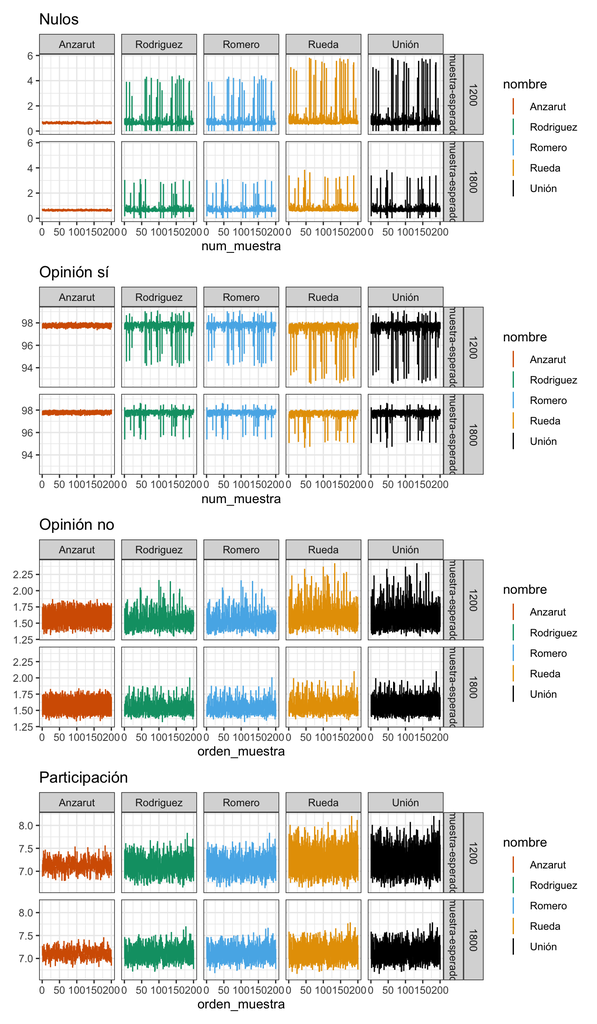

#### Intervalos individuales para muestra contaminada

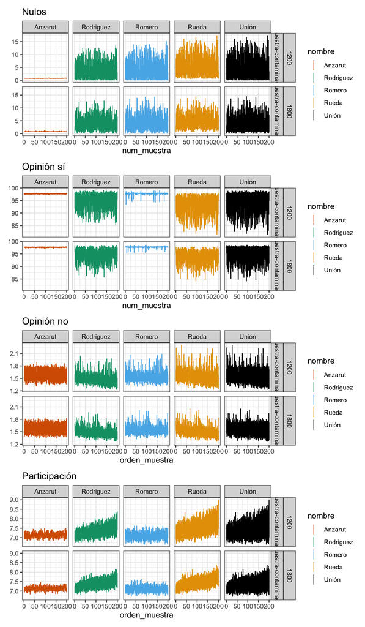

### Escenarios de cómputos

| opc | marco-2021 | marco-esperado | marco-sobre-corregido |
| --- | --- | --- | --- |
| nulos | 0.734 | 0.668 | 0.592 |
| opinion_no | 1.545 | 1.546 | 1.545 |
| opinion_si | 97.721 | 97.786 | 97.863 |
| part | 7.113 | 7.108 | 7.099 |
| n_marco | 57,077 | 57,074 | 57,032 |

### Coberturas: escenario marco-2021

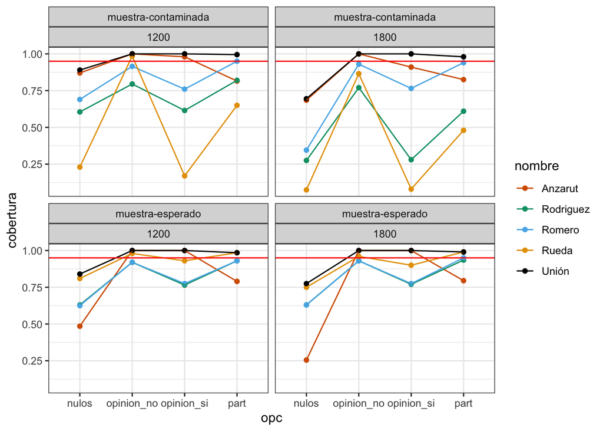

### Coberturas: escenario marco esperado (-3 casillas)

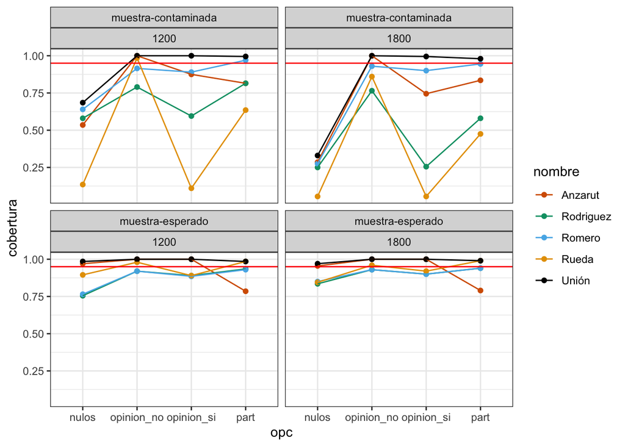

### Coberturas: escenario sobre corregido (-45 casillas)

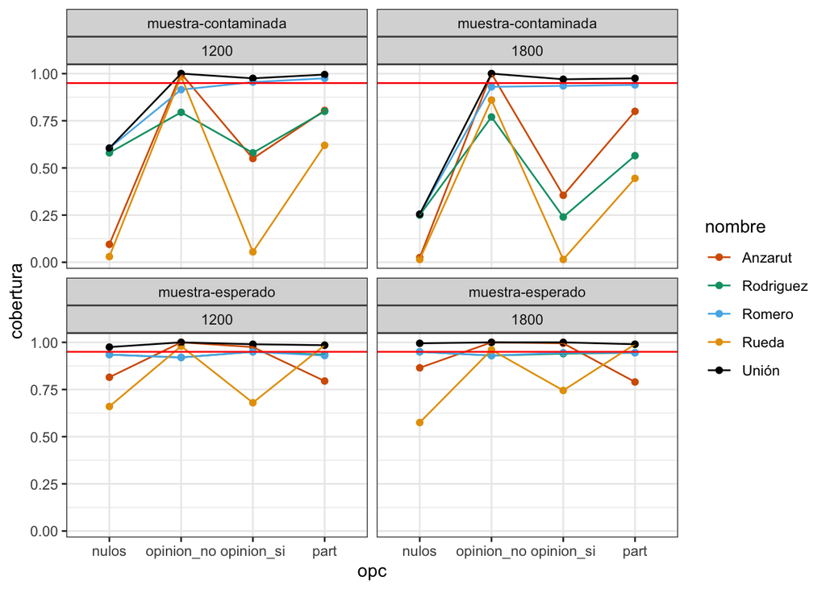

## Escenario marco esperado (-3 casillas), eliminando atípicos extremos

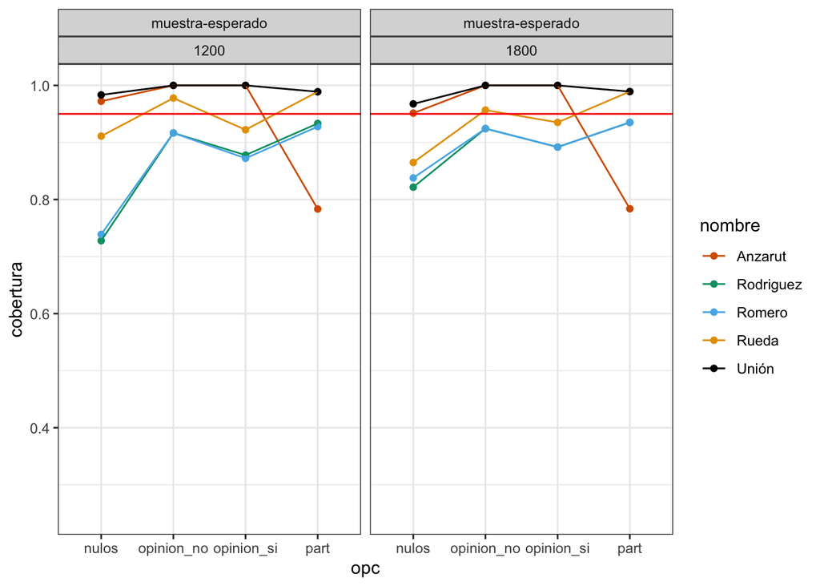

| opc | tam_muestra | tipo | Anzarut | Rodriguez | Romero | Rueda | Unión | Incremento_pct |
| --- | --- | --- | --- | --- | --- | --- | --- | --- |
| nulos | 1200 | muestra-esperado | 0.08 | 0.15 | 0.15 | 0.19 | 0.23 | 21.1 |
| nulos | 1800 | muestra-esperado | 0.07 | 0.14 | 0.14 | 0.14 | 0.17 | 21.4 |
| opinion_no | 1200 | muestra-esperado | 0.17 | 0.13 | 0.13 | 0.19 | 0.22 | 15.8 |
| opinion_no | 1800 | muestra-esperado | 0.15 | 0.10 | 0.10 | 0.12 | 0.16 | 6.7 |
| opinion_si | 1200 | muestra-esperado | 0.20 | 0.23 | 0.23 | 0.31 | 0.36 | 16.1 |
| opinion_si | 1800 | muestra-esperado | 0.19 | 0.19 | 0.19 | 0.21 | 0.25 | 19.0 |
| part | 1200 | muestra-esperado | 0.13 | 0.23 | 0.24 | 0.37 | 0.38 | 2.7 |
| part | 1800 | muestra-esperado | 0.11 | 0.19 | 0.19 | 0.24 | 0.24 | 0.0 |

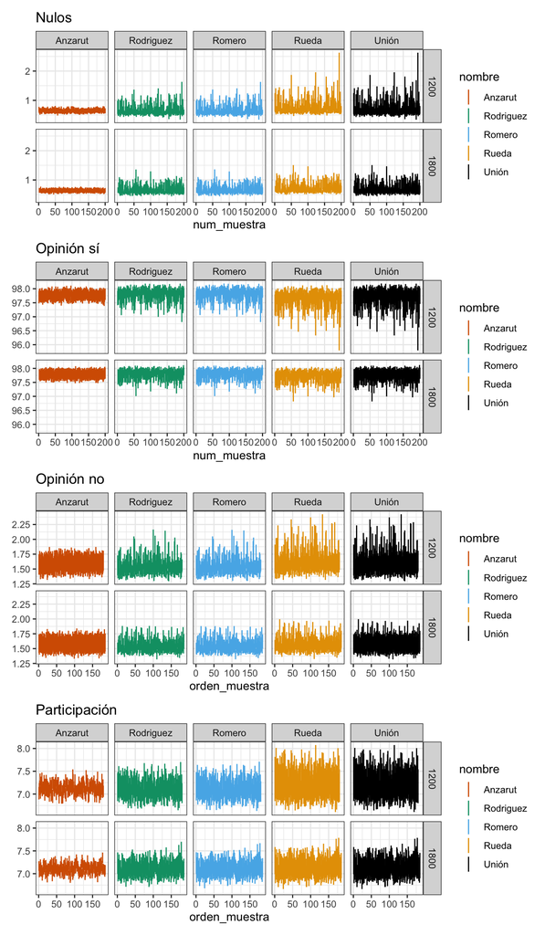